# SR_6_homework_CR

Christoph Rosa

2022-10-14

# Easy Questions

## Question 1

Omitted variable bias, post-treatment bias, and collider bias can lead to false inferences about causal relationships.

## Question 2

This chapter made me realize how often I must have fallen victim to post-treatment bias in the past.

Part of my BA thesis was a regression analysis that looked into correlations between voting districts’ demographics and the ideological position of their congressional representatives. I was mostly looking into how education (% of college-educated voters) and occupation (% of working-class employees) affect legislator ideology. In my regression models, I controlled for average income, missing the fact that income is most probably a path through which occupation and education indirectly affect voting behavior (and therefore the stances of elected representatives).

## Question 3

The “fork”, where X and Y are independent from each other, conditional on Z.

The “pipe”, where Z serves as a mediator for the relationship between X and Y, so conditioning on Z would erase their relation.

The “collider”, where X and Y are independent from each other but both influence Z, so conditioning on that middle variable reveals the “path” between them.

The “descendant”, a sort-of proxy variable D that contains information on its “parent” variable Z. Conditioning on D has an effect that depends on the role of Z (e.g., as a collider or a mediator in a pipe); this effect will be smaller than when conditioning directly on the parent variable Z.

## Question 4

Conditioning on a variable is somewhat like creating sub-samples of our (so far unbiased) sample. These sub-samples can be biased and therefore showcase correlations that do not represent any causal relatinoship.

If we think about the examples in the beginning of the chapter, conditioning on a collider variable such as “has been published” (influenced by both newsworthiness and trustworthiness), we create sub-samples of the data: One with published articles, one with rejected ones. Inside each of them we can detect a collinearity, even though newsworthiness and trustworthiness aren’t causally related.

# Medium Questions

## Question 1

Here is the DAG:

```r
library(tidyverse)
library(ggdag)
library(rethinking)
```

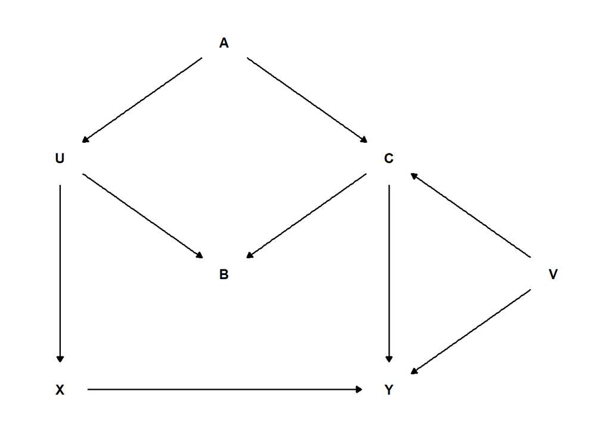

```r
# coordinates
dag_coords <-
  tibble(name = c("X", "Y", "U", "A", "B", "C", "V"),
         x    = c(1, 3, 1, 2, 2, 3, 4),
         y    = c(1, 1, 3, 4, 2, 3, 2))

# save our DAG
dag <-
  dagify(Y ~ X + C + V,
         X ~ U,
         B ~ U + C,
         U ~ A,
         C ~ A + V,
         coords = dag_coords)

# plot
dag %>%
  ggplot(aes(x = x, y = y, xend = xend, yend = yend)) +
  geom_dag_text(color = "black") +
  geom_dag_edges() +
  theme_dag()
```

This new graph includes two additional paths from X to Y, as each of the two original paths (p. 186) now comes with an alternative version where the ending segment C -> Y is replaced by C <- V -> Y.

The one of these two new paths that doesn’t run through the collider variable B needs to be closed.

As V isn’t another collider, but adds yet another fork, we can block it by simply conditioning on the new variable V.

## Medium 2

Let’s simulate data where X and Z are strongly correlated:

```r
# simulating data for X, Y, and Z
set.seed(123)
d <- tibble(x = rnorm(1000, 0, 1),
            z = rnorm(1000, x, 0.001),
            y = rnorm(1000, z, 1))

# and estimate our model
m <- quap(
  alist(
    y ~ dnorm(mu, sigma),
    mu <- a + b1 * x + b2 * z,
    a ~ dnorm(0, 1),
    b1 ~ dnorm(0, 1),
    b2 ~ dnorm(0, 1),
    sigma ~ dexp(1)
  ),
data = d
)

precis(m)
```

```
##              mean         sd       5.5%      94.5%
## a     -0.01977983 0.03089174 -0.0691508 0.02959113
## b1     0.47542949 0.70712308 -0.6546898 1.60554875
## b2     0.50509797 0.70706054 -0.6249213 1.63511728
## sigma  0.97721890 0.02183508  0.9423222 1.01211557
```

I don’t think this is a case of collinearity. In contrast to the leg example, where both variables (left leg/right leg) measured basically the same thing (leg length), here, Z is a mediator *through* which X influences Y.

## Medium 3

Top left: Condition on A and Z.

Top right: Condition on A.

Bottom left: None.

Bottom right: Condition on A.